# Morphology WFS - Option 2

Lauren O’Brien

2019-12-12

### Background

Experiments with extracting and formatting Queensland soils morphology data for WFS publication. Primary driver is the TERN SGLA II modelling (and particularly interface with the soil data federator https://github.com/RossDSearle/SoilDataFederatoR/) but the service should be useful to a wider range of clients as well.

```r
options(stringsAsFactors = FALSE, scipen = 999)
library(sf)            # vector data IO and processing
library(units)         # for working with unit-attributed data
library(tidyverse)     # general data manipulation and display
```

### ‘Flat’ conversion

This option emphasises minimising the number of layers in the service to align with the ‘join levels’ of Site, Observation, Horizon, Veg Community. Keeping samples and notes separate too.

```r
today <- '20191212'
sit_datafile <- file.path(getwd(), 'SALI_DATA',
                          paste0('SALI_SIT-data_', today, '.rds'))
decode_datafile <- file.path(getwd(), 'SALI_DATA',
                             paste0('SALI_SIT-data_decodes_', today, '.rds'))

sit_data <- readRDS(sit_datafile)
sit_data[['LAB']] <- NULL # out of scope still
decodes  <- readRDS(decode_datafile)
```

Pros:

- Simpler layer model
- Less repeated geometry data

Cons

- Smashing all the tables together neatly could be tricky - will need to alias some column names
- More repeated data from table joins, more NULL data
- Lose the ability to return useful created and updated dates
- Display could be odd??

#### Sites Layer

Requires reconciling tables SIT, SLU, SMP, SGE, SGP and spatialising using Obs 1.

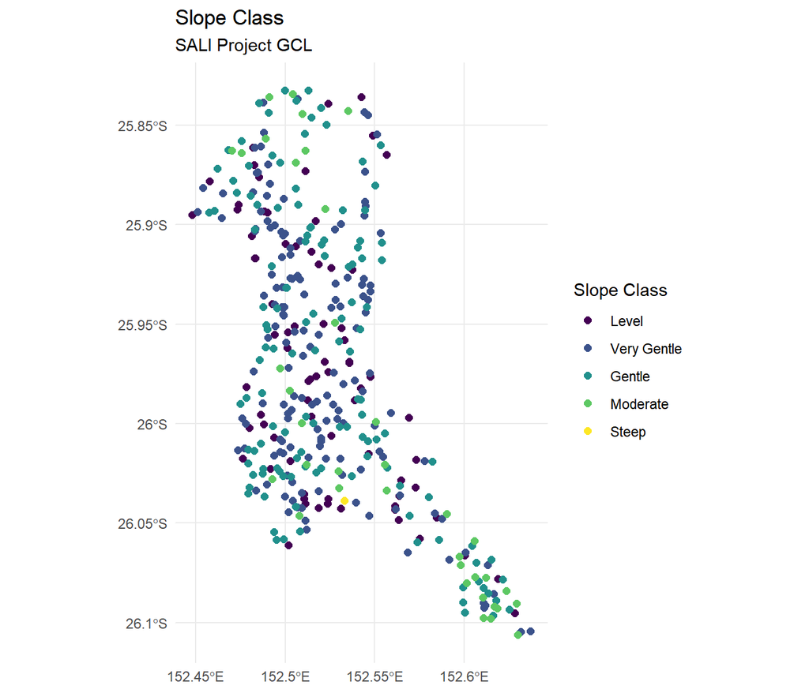

```
##  [1] "PROJECT_CODE"        "SITE_ID"             "TECH_REF_CODE"
##  [4] "GEOLOGY_CODE"        "PATT_TYPE_CODE"      "LOCAL_AUTH_CODE"
##  [7] "ELEM_TYPE_CODE"      "MAP_SCALE"           "MAP_SHEET_NO"
## [10] "SITE_TYPE"           "RAINFALL"            "SLOPE_EVAL_METHOD"
## [13] "SLOPE_PCT"           "SLOPE_CLASS"         "SLOPE_MORPH_TYPE"
## [16] "MODAL_SLOPE"         "ELEM_INC_SLOPE"      "ELEM_LENGTH"
## [19] "ELEM_WIDTH"          "ELEM_HEIGHT"         "ELEM_LOCATION"
## [22] "RELIEF"              "RELIEF_CLASS"        "REL_MOD_SLOPE_CLASS"
## [25] "STRM_CH_SPACING"     "STRM_CH_DEV"         "STRM_CH_DTOW"
## [28] "STRM_CH_MIG"         "STRM_CH_PATT"        "STRM_CH_NET_INT"
## [31] "STRM_CH_DIR_NET"     "LAND_USE_NO"         "LAND_USE_CODE"
## [34] "MAN_PRAC_NO"         "MAN_PRAC_CODE"       "ELEM_GEO_NO"
## [37] "ELEM_GEO_AGENT"      "ELEM_GEO_MODE"       "PATT_GEO_NO"
## [40] "PATT_GEO_AGENT"      "PATT_GEO_MODE"       "STATUS"
## [43] "geometry"
```

```r
site_data <- sit_data[1:5]
site_data <- lapply(site_data, function(x) {
  dplyr::select(x, -matches('CREAT'), -matches('UPDAT'))
  })

# context Proj code and context sid not in use on these projects so
site_data[['SIT']] <-
  dplyr::select(site_data[['SIT']], -CONTEXT_PROJECT_CODE, -CONTEXT_SITE_ID)

# duplicate column names in geomorph tables need aliasing
site_data[['SGE']] <- site_data[['SGE']] %>%
  rename(ELEM_GEO_AGENT = GEO_AGENT, ELEM_GEO_MODE = GEO_MODE)

site_data[['SGP']] <- site_data[['SGP']] %>%
  rename(PATT_GEO_AGENT = GEO_AGENT, PATT_GEO_MODE = GEO_MODE)

sites_layer <- reduce(site_data, full_join)

# spatialise
locs <- sit_data[['OLC']] %>%
  dplyr::filter(OBS_NO == 1) %>%
  st_as_sf(coords = c('LONGITUDE', 'LATITUDE'), crs = 4283) %>%
  dplyr::select(PROJECT_CODE, SITE_ID)

sites_layer <- right_join(locs, sites_layer, by = c('PROJECT_CODE', 'SITE_ID'))

names(sites_layer)

# e.g.
demo <- dplyr::filter(sites_layer, PROJECT_CODE == 'GCL') %>%
  dplyr::filter(!is.na(SLOPE_CLASS)) %>%
  mutate(SC = factor(SLOPE_CLASS,
                     levels = c('LE', 'VG', 'GE', 'MO', 'ST', 'VS', 'CL'),
                     labels = c('Level', 'Very Gentle', 'Gentle', 'Moderate',
                                'Steep', 'Very Steep', 'Cliffed'),
                     ordered = TRUE))

ggplot() +
  geom_sf(data = demo, aes(colour = SC), pch = 16, size = 2,
          show.legend = 'point') +
  scale_colour_viridis_d() +
  ggtitle("Slope Class", subtitle = "SALI Project GCL") +
  labs(colour = 'Slope Class') +
  theme_minimal()
```

#### Observations layer

Requires reconciling tables OBS, OLC, OCL, ODS, OSC, OMC, OER, OCF, OTC, OSM

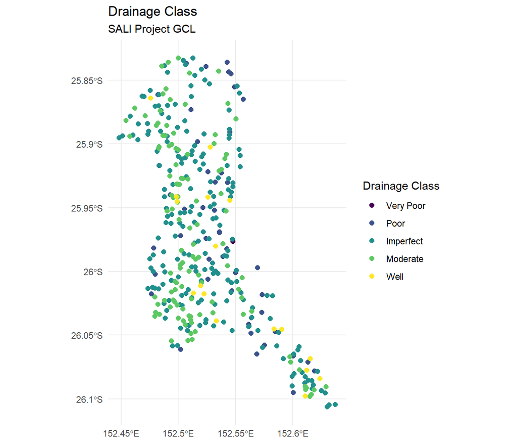

```
##   [1] "PROJECT_CODE"          "SITE_ID"               "OBS_NO"
##   [4] "OBS_DATE"              "OBS_TYPE"              "MAP_REF_TYPE"
##   [7] "USER_ID"               "PHOTO_NO"              "LAND_USE_CODE"
##  [10] "LITH_CODE"             "MASS_GEN_TYPE_CODE"    "REASON_CODE"
##  [13] "LOC_MEAS_METHOD"       "PHOTO_REF_EAST"        "PHOTO_REF_NORTH"
##  [16] "ASPECT"                "ELEVATION_EVAL_METHOD" "ELEVATION"
##  [19] "DRAINAGE_EVAL_METHOD"  "DRAINAGE_HEIGHT"       "DRAINAGE"
##  [22] "MICRO_SAMPLED"         "AGGRADATION"           "INUND_FREQ"
##  [25] "INUND_DURATION"        "INUND_DEPTH"           "INUND_RUNON_VELOCITY"
##  [28] "DEPTH_WATER"           "DEPTH_RHORIZON"        "RUNOFF"
##  [31] "PERMEABILITY"          "SUBS_OBS_TYPE"         "SUBS_DISTANCE"
##  [34] "SUBS_CONFIDENCE"       "SUBS_DEPTH"            "SUBS_GRAIN_SIZE"
##  [37] "SUBS_TEXTURE"          "SUBS_STRUCTURE"        "SUBS_POROSITY"
##  [40] "SUBS_STRENGTH"         "SUBS_MASS_DISC_SPAC"   "SUBS_MASS_ALTERATION"
##  [43] "SUBS_MASS_STRENGTH"    "SUBS_SPEC_FEATURES"    "SITE_MAN_PRAC"
```

[output cut: 19 more lines]

```r
obs_data <- sit_data[7:16]
obs_data <- lapply(obs_data, function(x) {
  dplyr::select(x, -matches('CREAT'), -matches('UPDAT'))
  })

# redundant redundant
obs_data[['OLC']] <- NULL

# going to separate obs level veg data out
obs_data[['OBS']] <- obs_data[['OBS']] %>%
  dplyr::select(-FOREST_TYPE, -matches('RAINFOR'), -SCLEROPHYLL)

obs_layer <- reduce(obs_data, full_join) # still not quite right?? check

locs <- sit_data[['OLC']] %>%
  st_as_sf(coords = c('LONGITUDE', 'LATITUDE'), crs = 4283) %>%
  dplyr::select(PROJECT_CODE, SITE_ID, OBS_NO)

obs_layer <-
  right_join(locs, obs_layer, by = c('PROJECT_CODE', 'SITE_ID', 'OBS_NO'))

names(obs_layer)

# e.g.
demo <- dplyr::filter(obs_layer, PROJECT_CODE == 'GCL') %>%
  dplyr::filter(!is.na(DRAINAGE)) %>%
  mutate(DG = factor(DRAINAGE,
                     levels = c(1, 2, 3, 4, 5, 6),
                     labels = c('Very Poor', 'Poor', 'Imperfect', 'Moderate',
                                'Well', 'Very Well'),
                     ordered = TRUE))

ggplot() +
  geom_sf(data = demo, aes(colour = DG), pch = 16, size = 2,
          show.legend = 'point') +
  scale_colour_viridis_d() +
  ggtitle("Drainage Class", subtitle = "SALI Project GCL") +
  labs(colour = 'Drainage Class') +
  theme_minimal()
```

#### Horizons layer

Requires reconciling tables HOR, HSX, HCO, HMT, HCF, HST, HSG, HFB, HCU, HCR, HMP, HGT, HPA, HRT, FTS

Skipping HSX as all the data actually appears in HOR$HORIZON_NAME

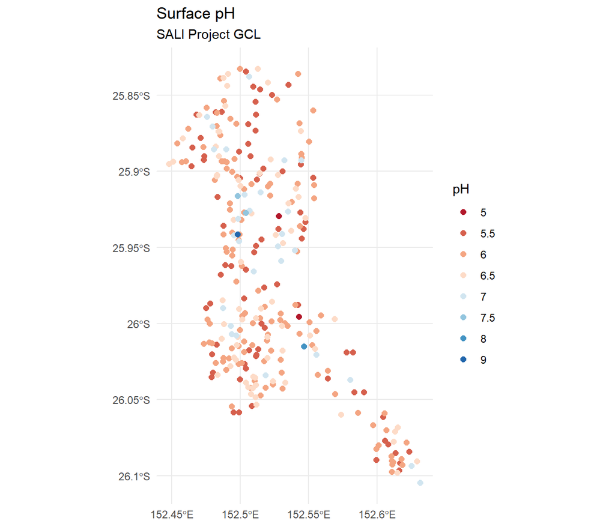

```r
hor_data <- sit_data[20:34]
hor_data[['HSX']] <- NULL
hor_data <- lapply(hor_data, function(x) {
  dplyr::select(x, -matches('CREAT'), -matches('UPDAT'))
  })

# also need hex colours
hex_cols <- read_csv(file.path(getwd(), 'helpers', 'translated_colours.csv')) %>%
  dplyr::select(COLOUR_BOOK, COLOUR_CODE, HEX)

# so much aliasing augh
hor_data[['HOR']] <- hor_data[['HOR']] %>%
  rename(HOR_BOUND_DISTINCT = BOUND_DISTINCT, HOR_BOUND_SHAPE = BOUND_SHAPE)

hor_data[['HCO']] <- hor_data[['HCO']] %>%
  left_join(hex_cols, by = c('COLOUR_BOOK', 'COLOUR_CODE')) %>%
  rename(HOR_COLOUR_BOOK = COLOUR_BOOK, HOR_COLOUR_CODE = COLOUR_CODE,
         HOR_MOISTURE_STAT = MOISTURE_STAT, HOR_HEXCODE = HEX)

hor_data[['HMT']] <- hor_data[['HMT']] %>%
  left_join(hex_cols, by = c('COLOUR_BOOK', 'COLOUR_CODE')) %>%
  rename(MOTT_COLOUR_BOOK = COLOUR_BOOK, MOTT_COLOUR_CODE = COLOUR_CODE,
         MOTT_MOISTURE_STAT = MOISTURE_STAT, MOTT_HEXCODE = HEX,
         MOTT_CONTRAST = CONTRAST, MOTT_ABUNDANCE = ABUNDANCE,
         MOTT_BOUND_DISTINCT = BOUND_DISTINCT)

hor_data[['HCF']] <- hor_data[['HCF']] %>%
  rename(COARSE_FRAG_ABUNDANCE = ABUNDANCE, COARSE_FRAG_LITH_CODE = LITH_CODE,
         COARSE_FRAG_SHAPE = SHAPE, COARSE_FRAG_STRENGTH = STRENGTH,
         COARSE_FRAG_DISTRIBUTION = DISTRIBUTION,
         COARSE_FRAG_ALTERATION = ALTERATION )

# structures is ok

hor_data[['HSG']] <- hor_data[['HSG']] %>%
  rename(SEG_ABUNDANCE = ABUNDANCE, SEG_NATURE = NATURE,
         SEG_STRENGTH = STRENGTH, SEG_MAGNETIC_ATTRIB = MAGNETIC_ATTRIB)

hor_data[['HFB']] <- hor_data[['HFB']] %>%
  rename(FAB_ABUNDANCE = ABUNDANCE)

hor_data[['HCU']] <- hor_data[['HCU']] %>%
  rename(CUTAN_ABUNDANCE = ABUNDANCE, CUTAN_DISTINCTNESS = DISTINCTNESS)

hor_data[['HCR']] <- hor_data[['HCR']] %>%
  rename(CRACK_WIDTH = WIDTH)

hor_data[['HMP']] <- hor_data[['HMP']] %>%
  rename(MACRO_ABUNDANCE = ABUNDANCE, MACRO_DIAMETER = DIAMETER)

hor_data[['HGT']] <- hor_data[['HGT']] %>%
  rename(STREN_CLASS = CLASS, STREN_WATER_STAT = WATER_STAT)

hor_data[['HPA']] <- hor_data[['HPA']] %>%
  rename(PAN_CEMENTATION = CEMENTATION, PAN_CONTINUITY = CONTINUITY,
         PAN_STRUCTURE = STRUCTURE)

hor_data[['HRT']] <- hor_data[['HRT']] %>%
  rename(ROOT_ABUNDANCE = ABUNDANCE)

hor_data[['FTS']] <- hor_data[['FTS']] %>%
  rename(FIELD_TEST_NO = TEST_NO, FIELD_TEST_TYPE = TEST_TYPE,
         FIELD_TEST_DEPTH = DEPTH, FIELD_TEST_VALUE = VALUE,
         FIELD_TEST_METHOD = METHOD)

horizon_layer <- reduce(hor_data, full_join) %>%
  right_join(locs, ., by = c('PROJECT_CODE', 'SITE_ID', 'OBS_NO'))

# e.g.
bundy_ph <- dplyr::filter(horizon_layer, PROJECT_CODE == 'GCL' &
                              FIELD_TEST_TYPE == 'PH' & FIELD_TEST_METHOD == 1 &
                              HORIZON_NO == 1 & FIELD_TEST_NO == 1)

ggplot() +
  geom_sf(data = bundy_ph, aes(colour = FIELD_TEST_VALUE), pch = 16, size = 2,
          show.legend = 'point') +
  scale_colour_brewer(palette = 'RdBu') +
  ggtitle("Surface pH", subtitle = "SALI Project GCL") +
  labs(colour = 'pH') +
  theme_minimal()
```

#### Vegetation Layer

Requires reconciling VCM, VST, VSP plus veg data from OBS

```r
veg_data <- sit_data[c(7, 17:19)]

veg_data <- lapply(veg_data, function(x) {
  dplyr::select(x, -matches('CREAT'), -matches('UPDAT'))
  })

veg_data[['OBS']] <- veg_data[['OBS']] %>%
  dplyr::select(PROJECT_CODE, SITE_ID, OBS_NO,
                FOREST_TYPE, matches('RAINFOR'), SCLEROPHYLL)

veg_data[['VCM']] <- veg_data[['VCM']] %>%
  rename(VEG_COMM_NAME = NAME, VEG_COMM_DESCRIPTION = DESCRIPTION) %>%
  # not in use
  dplyr::select(-REF_VEG_COMM_NO)

vegetation_layer <- reduce(veg_data, full_join) %>%
  right_join(locs, ., by = c('PROJECT_CODE', 'SITE_ID', 'OBS_NO'))
```

#### Notes

Just needs to be spatialised

```r
notes_layer <- right_join(locs, sit_data[['NOT']],
                          by = c('PROJECT_CODE', 'SITE_ID', 'OBS_NO')) %>%
  dplyr::select(-matches('CREAT'), -matches('UPDAT'))
```

#### Samples

As for notes

```r
samples_layer <- right_join(locs, sit_data[['SAM']],
                            by = c('PROJECT_CODE', 'SITE_ID', 'OBS_NO')) %>%
  dplyr::select(-matches('CREAT'), -matches('UPDAT'))
```

### Assemble

```r
flat_service <- list(sites_layer, obs_layer, horizon_layer, vegetation_layer,
                     samples_layer, notes_layer)
names(flat_service) <- c('soil_sites', 'soil_observations', 'soil_horizons',
                         'vegetation', 'soil_samples', 'notes')
saveRDS(flat_service,
        file.path(getwd(), 'DERIVED_DATA', 'SALI_Morph_Spatial_flat.rds'))
# flat_service <- readRDS(file.path(getwd(), 'DERIVED_DATA', 'SALI_Morph_Spatial_flat.rds'))
```

Quite a bit smaller than the simple conversion.

### Output

Writing to FGDB for use in Arc:

```r
# NB currently experiencing problems using reticulate and arcgisbinding in the
# same session - one prevents the other finding the license >:-(
test_gdb <- file.path(getwd(), 'DERIVED_DATA', 'TEST_02_FLAT.gdb')

if(!(dir.exists(test_gdb))) {
  # launch access to arcpy
  library(reticulate)
  arcpy3_dir <- 'C:/Program Files/ArcGIS/Pro/bin/Python'
  system2(file.path(arcpy3_dir, 'Scripts', 'proenv.bat'))
  # make an empty file geodatabase
  arcpy <- import('arcpy')
  arcpy$CreateFileGDB_management(file.path(getwd(), 'DERIVED_DATA'),
                                 'TEST_02_FLAT.gdb')
}
```

```r
library(arcgisbinding) # arcgis interface
arc.check_product()

purrr::map2(flat_service, names(flat_service), function(lyr, nm) {
  arc.write(file.path(test_gdb, nm), lyr, overwrite = TRUE)
})
```